# ANA 515 Assignment 2

PRASANTH MANUPURI

2023-06-22

# Package Loading

```r
library(readr)
library(ggplot2)
```

# Data Importation

```r
Abalone <- read_csv("Abalone.csv")
```

# Visualization 1

The first visualization presented below in Figure 1 is the histogram of the length variable from the Abalone data set. The histogram presents information about the distribution of the length variable data in the abalone data set. The histogram shows that the data is skewed to the left, implying that the majority of the data is on the top half and top third of the range of the data. Therefore, the data on the length in this case is skewed and not normally distributed.

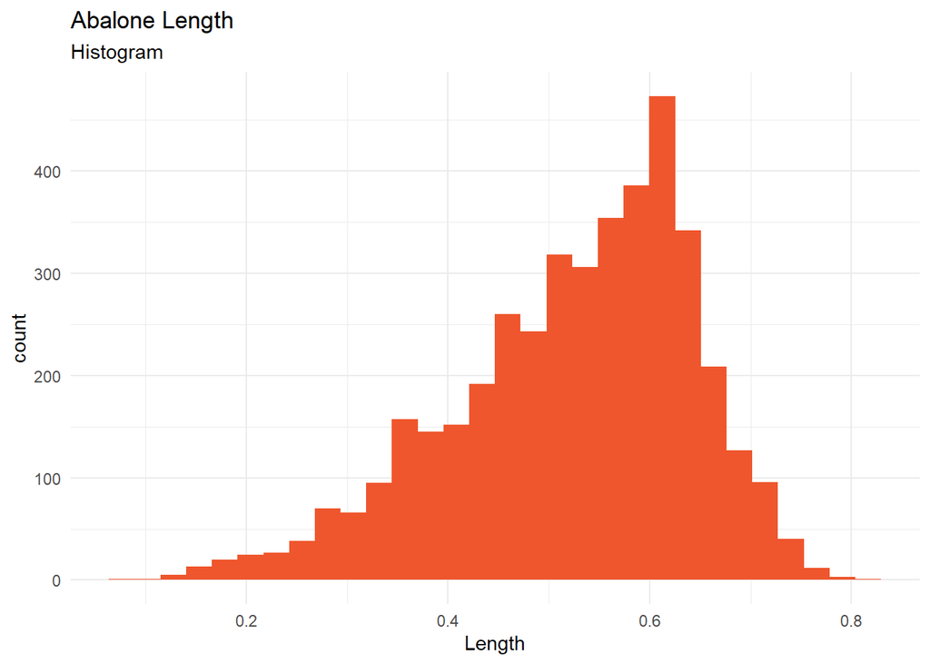

Figure 1

```r
ggplot(Abalone) +
  aes(x = Length) +
  geom_histogram(bins = 30L, fill = "#EF562D") +
  labs(title = "Abalone Length ", subtitle = "Histogram") +
  theme_minimal()
```

# Visualization 2

The second visualization presented below in Figure 2 is the scatter plot of the length of the abalone against the whole weight of the abalone. The interest in producing this plot is to understand how the length of an abalone is related to the weight of the abalone. This investigation aims at arriving at the determination of whether the longer and abalone is there heavier it weighs, or the contrary. The scatter plot presents the best visualization option for this investigation since the data points plotted for length and whole weight show the overall picture of the interaction of the two across the data. In the scatter plot, we note that in general there is an increasing trend with data points forming a pattern from bottom left to top right. Therefore, as an abalone grows longer, its weight also increases. An interesting observation is that the increasing pattern appears to be more curved that linear.

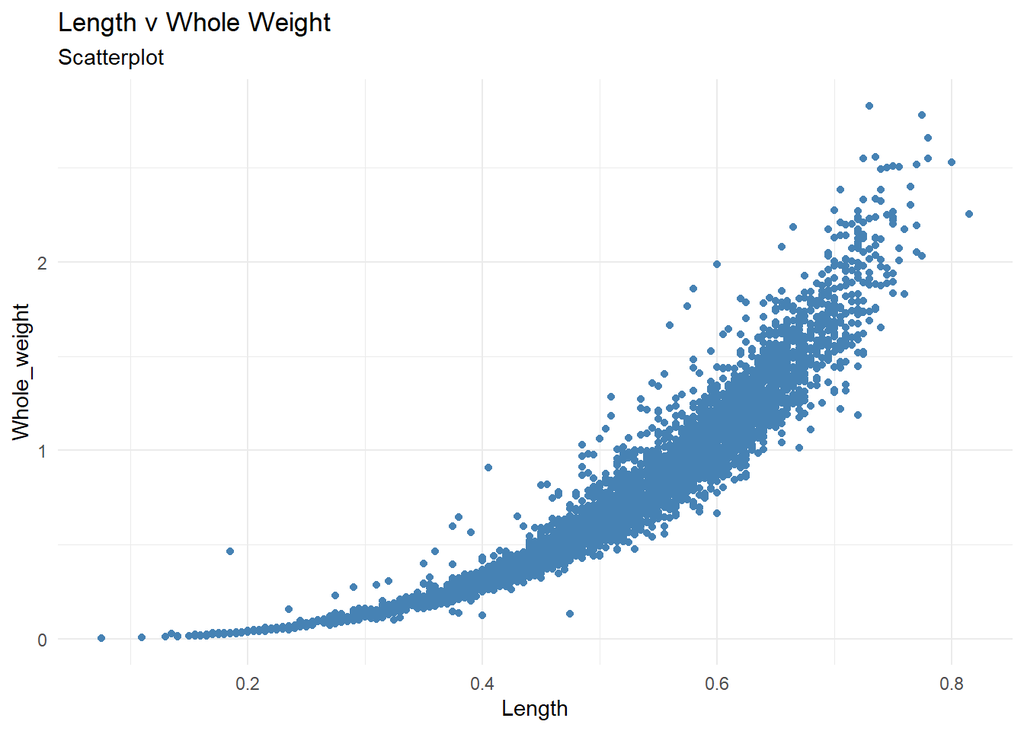

Figure 2

```r
ggplot(Abalone) +
  aes(x = Length, y = Whole_weight) +
  geom_point(shape = "circle", size = 1.5, colour = "#4682B4") +
  labs(
    title = "Length v Whole Weight",
    subtitle = "Scatterplot"
  ) +
  theme_minimal()
```